# Movies rates - Reproducible Pitch

March 11, 2018

## Overview

I have built this presentation as part of aa assignment of the course Developing Data Products as part of the Coursera Data Science Specialization.

## Web Application functionality

The applications allows users to make visual estimations and dependencies of different parameters. The parameters are optional user inputs. User can choice parameters on the x axis as well as on the y axis. The available parameters on th input are:

- IMDB rating
- IMDB number of votes
- Critics Score
- Audience Score and Runtime.

User is allowed to change the size of point on the output scatterplot, he/she can input appropriate Title of the output, subset the output movies by genre and change the size of the sample on the output.

## Dataset

The internet movie database, imdb.com, is a website devoted to collecting movie data supplied by studios and fans. It claims to be the biggest movie database on the web and is run by Amazon. More about information imdb.com can be found online, including information about the data collection process.

IMDB makes their raw data available. The DataCamp provides the dataset from years 1970 - 2017 containig 651 titels on the url: "http://s3.amazonaws.com/assets.datacamp.com/production/course_4850/datasets/movies.Rdata" Movies were selected for inclusion if they had a known length and had been rated by at least one IMDB user.

## Dataset Fields

The final output contains the following fields:

```
 [1] "title"            "title_type"       "genre"
 [4] "runtime"          "mpaa_rating"      "studio"
 [7] "thtr_rel_date"    "thtr_rel_year"    "thtr_rel_month"
[10] "thtr_rel_day"     "dvd_rel_date"     "dvd_rel_year"
[13] "dvd_rel_month"    "dvd_rel_day"      "imdb_rating"
[16] "imdb_num_votes"   "critics_rating"   "critics_score"
[19] "audience_rating"  "audience_score"   "best_pic_nom"
[22] "best_pic_win"     "best_actor_win"   "best_actress_win"
[25] "best_dir_win"     "top200_box"       "director"
[28] "actor1"           "actor2"           "actor3"
[31] "actor4"           "actor5"           "imdb_url"
[34] "rt_url"
```

## Sample of Output with Plot

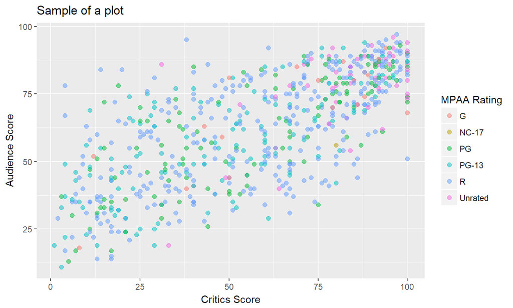